# The AI Landscape

Lecture 10a  
POLS 6394 · Tuesday, October 27

## Today

- Models, applications, and agents; cloud versus local
- How fast this has moved, including a new study of AI peer review
- Web chat versus agents, and why most people haven’t seen the difference
- Subscriptions and API credit

Lecture 11a continues this lesson on November 3: installing your tools, then how models work, costs, and the debate over AI in research.

Part II begins after the midterm. AI use is required on Part II assignments; **Problem Set 5 stays AI-off**.

# What these tools are

## Company, model, application

A **large language model (LLM)** generates text from the instructions and context it receives.

| Term | What it means | Example |
| --- | --- | --- |
| Company | Develops or provides the service | OpenAI, Anthropic |
| Model | The trained system that generates responses | GPT-6 Luna, Claude Sonnet 5.5 |
| Application | The interface and tools you use | ChatGPT, Claude Code |

One application may offer several models. The application also affects what the model can see and do.

## Frontier models and the rest

- They cost the most to train and the most to use.
- They’re the ones that can run long agent tasks, plan, debug, and finish.

**Everything else** is smaller, cheaper, or older: GPT-6 Luna, Claude Haiku, last year’s flagships. These are fine for simple, well-defined tasks, such as coding one survey answer at a time.

The frontier moves. This year’s frontier model is next year’s cheap one.

## Open-weight versus closed models

A model’s **weights** are the billions of numbers learned in training. They *are* the model.

|  | Closed | Open-weight |
| --- | --- | --- |
| Examples | GPT, Claude, Gemini | Llama, Qwen, DeepSeek, gpt-oss |
| Weights | Kept by the company | Anyone can download them |
| How you use it | The company’s app or API | Your computer, or any cloud provider |
| Cost | Set by the company | Often much cheaper |
| Capability | Includes the frontier | Substantially behind the frontier |

People often call open-weight models “open source.” Strictly, open source would also release the training data and code, and most don’t.

Open weights also help research: a downloaded model never changes, so others can rerun your analysis with the same model.

[Open Source Initiative: Open Source AI Definition](https://opensource.org/ai/open-source-ai-definition)

## Where the model runs

| Cloud | Local |
| --- | --- |
| A provider runs the model on its servers | You run downloaded model files on your computer |
| Little local computing power needed | Memory and computing power limit what fits |
| You depend on the provider’s availability | You maintain the model and its software |

A terminal agent can use a cloud model. A chat interface can use a local model. The interface doesn’t tell you where the computation happens.

## Hardware for local models

For this course, **use cloud models unless you already have suitable hardware**. Don’t buy a new computer for the class.

- Apple Silicon **Pro, Max, or Ultra**: 32 GB unified memory is a useful starting target; 64 GB or more gives more room for larger models.
- A capable gaming or workstation PC: a supported discrete GPU, with enough dedicated **VRAM**, the GPU’s own memory.

These are course recommendations, not minimums. Small models can run on less hardware, usually with more compromises in speed or capability.

[LM Studio: requirements](https://lmstudio.ai/docs/app/system-requirements) · [Ollama: supported hardware](https://docs.ollama.com/gpu)

## Agents and tools

A **tool** lets the application do something outside the model: read a file, search a page, or run a command.

An **agent** can choose a sequence of tool calls, inspect the results, and decide what to try next.

The **harness** is the application that manages this loop and the model’s access to tools.

For a coding task, it might edit a QMD, render it, read an error, and revise the code. Its permissions determine which actions it can take.

[Codex CLI](https://learn.chatgpt.com/docs/cli)

# How fast this has moved

## Less than four years

| When | What happened |
| --- | --- |
| Nov 2022 | ChatGPT launches: most people’s first conversation with an LLM |
| Mar 2023 | GPT-4 |
| Sep 2024 | OpenAI o1, the first widely used **reasoning** model: it works through a problem before answering |
| Jan 2025 | DeepSeek-R1, a downloadable reasoning model from China |
| Feb 2025 | Claude Code preview: a coding agent in the terminal |
| Apr 2025 | OpenAI’s Codex CLI |
| Aug 2025 | GPT-5 |
| Nov 2025 | **Claude Opus 4.5 in Claude Code**; Gemini 3; GPT-5.1-Codex-Max |
| Dec 2025 | Over the holidays, many programmers find agents can carry real projects |
| Apr 2026 | Claude Mythos Preview, withheld from public release, goes to security partners |
| Sep 2026 | New frontier (most capable) models: Fable 5.1, GPT-6 Astra |
| Sep 2026 | Near-frontier at lower prices: Claude Opus 5.5, GPT-6 Sol and Luna, GPT-6.1 Sol |

Every coding agent in this course is less than two years old.

Month of public release or announcement, from developer announcements and news coverage: [Claude Opus 4.5](https://www.anthropic.com/news/claude-opus-4-5) · [Claude Fable and Mythos 5.1](https://www.anthropic.com/claude-fable-and-mythos-5-1)

## December 2025: agents start to work

Through most of 2025, coding agents helped with pieces of a task. Long tasks often drifted, stalled, or broke something.

Late-2025 models changed that, above all Claude Opus 4.5 running in Claude Code, along with OpenAI’s Codex models. Around the December holidays, many experienced programmers found that agents could plan, write, run, debug, and finish work that had taken them hours or days.

> “I’ve never felt this much behind as a programmer. The profession is being dramatically refactored.” — Andrej Karpathy, December 26, 2025

Karpathy co-founded OpenAI, ran AI for Tesla’s self-driving cars, and coined “vibe coding.” When he says he’s behind, programmers listen.

That’s roughly the technology you’ll supervise in Part II, and it has improved since.

[Anthropic: Claude Opus 4.5](https://www.anthropic.com/news/claude-opus-4-5) · [Karpathy’s post, as reported](https://www.businesstoday.in/technology/news/story/never-felt-this-behind-openai-co-founder-admits-ai-is-evolving-so-fast-its-refactoring-how-developers-work-508391-2025-12-28)

## How long a task can an AI agent finish?

[METR](https://metr.org/time-horizons/) gives agents software tasks and records how long each takes a skilled person. A model’s score is the length of task, in **human** hours, that it completes about half the time.

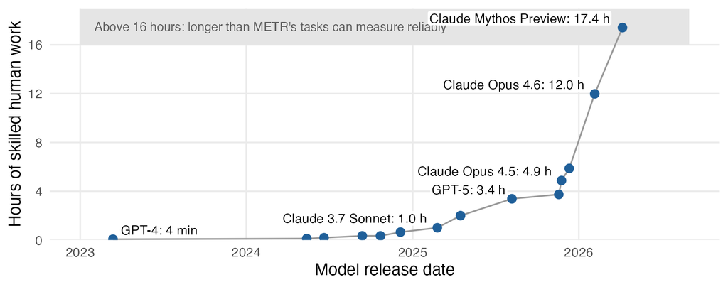

METR 50% time horizon of frontier models by release date, from 4 minutes for GPT-4 to about 17 hours for Claude Mythos Preview

Since 2023 this length has doubled about every four months. Past 16 hours, the estimates are rough.

[METR time horizons](https://metr.org/time-horizons/), Time Horizon 1.1 results, frontier models only (downloaded October 27, 2026). METR stopped updating in September 2026, so Fable 5.1 and GPT-6 aren’t measured.

## What those hours mean

| Horizon | Models | A job that size (illustrative) |
| --- | --- | --- |
| 4 minutes | GPT-4, 2023 | Fix one line of code |
| 1 hour | Claude 3.7 Sonnet, early 2025 | Write and debug a short script |
| 3–5 hours | GPT-5 to Claude Opus 4.5, late 2025 | An afternoon: clean a dataset and build its pipeline |
| 12–17 hours | Claude Opus 4.6 and Mythos, 2026 | Two working days: a feature in code it hasn’t seen |

- **About 8 times longer each year.** On the chart that looks flat, then a wall. Late 2025 is when afternoon-sized jobs came within reach.
- **Half the time isn’t reliable.** At 80% success the horizons shrink: Mythos to about 3 hours, GPT-5 to about 40 minutes.
- **Real research is messier.** METR’s tasks are clean and scored automatically. In METR’s 2025 field study, experienced developers worked *slower* with early-2025 AI tools, while believing they were faster.

**In 2023, a five-minute task. Now, two days of work, done half the time. Your job shifts from doing the work to checking it.**

[METR time horizons](https://metr.org/time-horizons/) (80% horizons from the same results) · [METR field study, July 2025](https://metr.org/blog/2025-07-10-early-2025-ai-experienced-os-dev-study/)

## Your tools are newer than this semester

- The semester began August 25. In September came two new frontier models, Claude Fable 5.1 and GPT-6 Astra.
- Within weeks, cheaper refinements came close to them: Claude Opus 5.5 lists at $4 per million input tokens (pieces of text sent) and $20 per million output tokens, against Fable 5.1’s $10 and $50, and OpenAI says GPT-6.1 Sol nearly matches Astra at about a fifth of the price.
- The syllabus, written this summer, names GPT-5.6. Its successor arrived before the midterm.
- A claim about what AI “can’t do” may be a year out of date, including in published studies. Check the model and the date before you accept a claim, positive or negative.

# What most people see

## What most Americans see

- In late 2025, **fewer than 1 in 10 Americans** paid for an AI subscription; OpenAI led with 4.6%.
- Bank of America’s payments data, March 2026: about **3% of households** pay for AI services.
- A majority of Americans use AI weekly (same survey): most users aren’t **personally paying**.

| Plan | Coding agent and its model |
| --- | --- |
| ChatGPT Free | Codex with GPT-6 Luna, quick tasks only |
| ChatGPT Plus ($20) | Codex with GPT-6.1 Sol (offered in Codex and Work, not in chat) |
| Claude Free | None; chat with Sonnet and Haiku |
| Claude Pro ($20) | Claude Code with Opus, Sonnet, and Haiku |

[Epoch AI / Blue Rose Research survey of 5,660 Americans](https://epochai.substack.com/p/polling-on-ai-usage), late 2025 · [Bank of America Institute](https://institute.bankofamerica.com/economic-insights/consumer-ai-usage.html), March 2026 · Plans checked October 26, 2026: [ChatGPT](https://learn.chatgpt.com/docs/pricing); [Claude](https://claude.com/pricing)

## Free chat isn’t the frontier

- Free ChatGPT’s coding agent uses **GPT-6 Luna**, OpenAI’s small model. Its API price is one-twentieth of GPT-6.1 Sol’s.
- Even a paying ChatGPT user who stays in the chat window doesn’t get Sol. OpenAI offers it in Codex and Work.
- The agent pairings in the timeline (Claude Code with Opus, Codex with Sol) aren’t in the free tiers. Free ChatGPT offers Codex only for quick tasks, with Luna.

A free-chat experience doesn’t tell you what a project-connected agent can do. Ask which model, which application, and when.

That’s why this course has you pay for two months of ChatGPT Plus: you’ll supervise the tools most people haven’t seen.

# Political science is already changing

## LLMs are now research tools

Political scientists already use language models to:

- **Annotate text at scale:** code speeches, news stories, or open-ended survey answers. On well-defined tasks, models can match trained coders, at a fraction of the cost.
- **Simulate respondents** (“silicon sampling”): give a model a demographic profile, ask survey questions, and compare its answers with real respondents.
- **Interview people:** an AI interviewer asks follow-up questions in an open-ended survey.
- **Review research:** more in two slides.

Each use needs validation against people or known answers. A model that matches coders on one task may not on the next.

[Gilardi, Alizadeh & Kubli 2023](https://doi.org/10.1073/pnas.2305016120) · [Argyle et al. 2023](https://doi.org/10.1017/pan.2023.2) · Kennedy, Shor & Austin, *Large Language Models for Public Opinion Research*, Cambridge Elements

## From R: the ellmer package

Research uses like these run as code, not in a chat window. The **ellmer** package, from Posit (the company behind RStudio), gives you one R interface to many models. Each provider’s API has its own formats and quirks; ellmer hides them, so a prompt goes out from R and the answer comes back into R the same way.

```r
library(ellmer)
chat <- chat_openai()  # finds your OpenAI API key in .Renviron
chat$chat("Code this answer as economy, health, or other: 'Groceries cost too much.'")
```

- Put that call in a loop and you can code 2,000 survey answers, one row each, in a data frame.
- Switching models means changing one line: `chat_anthropic()`, `chat_google_gemini()`, or a model on your own computer with `chat_ollama()`. The rest of your code stays put.
- Each call is billed to your API credit, and your script is a record of exactly what you asked.

You’ll use ellmer in Part II for text annotation and silicon sampling.

[ellmer documentation](https://ellmer.tidyverse.org/)

## Just out: AI reviews beat expert peer reviews

[King and Worthington](https://gking.harvard.edu/peerless) compared AI and human reviews of the same 124 manuscripts. The 134 human reviews came from Harvard’s rapidPeer service: paid experts, carefully chosen, whose reviews authors and former editors rated unusually highly.

Claude Opus 4.8, at its maximum reasoning setting, reviewed each paper twice: once with only the reviewer instructions, and once with a purpose-built prompt and **web search** (12.4 searches per review on average). The results below use the second; the first did almost as well.

- An AI judge from another company (GPT-5.5) preferred the AI review in **every decided pair (132 of 132)**.
- Three former journal editors each judged the same 10 pairs, not told that one review was AI. They preferred it in **26 of 30** picks.
- **5.5%** of the AI reviews’ claims about the manuscript were judged incorrect, against **15.9%** for the human reviews. The AI reviews cited no fabricated sources.

Gary King & Steven Worthington, *AI Article Reviews Dominate Human Peer Reviews at Their Best: Evidence and Policy Choices*, working paper, October 25, 2026.

## Journals now allow AI, if you disclose it

The *American Journal of Political Science* revised its AI policy on August 11, 2026.

- Authors may use AI “only as a companion” to their work, never “as a replacement for their own judgment.”
- Declare any use that shaped the research or the manuscript: text, code, data collection, analysis, figures, research design. Name each tool and its provider, the tasks, and who checked the output.
- Spelling and formatting fixes need no disclosure. Anything touching data or analysis does, “however minor.”
- AI can’t be an author. Invented citations are out.
- “Failure to disclose AI use as required by this policy is itself grounds for decline.”
- Reviewers may not upload a manuscript under review to an AI tool.

The practical lesson: record what AI did while you work, not when you submit.

[AJPS AI Policy, updated August 11, 2026](https://ajps.org/ajps-ai-policy/) · [Announcement](https://ajps.org/2026/08/11/revised-ajps-artificial-intelligence-ai-policy-for-authors-and-reviewers/)

# From chat to agents

## Web chat versus an agent harness

|  | Typical web chat | Agent harness in your project |
| --- | --- | --- |
| What it sees | What you type, paste, or upload | Any file in the project it’s allowed to read: data, code, rendered output, error messages. It finds and re-reads what it needs |
| How context grows | You decide what to paste | It opens the files it needs and reads the results of what it runs |
| Who runs the code | You copy, paste, run, and report back | It runs the code and reads the output itself |
| When its context (what the model can see at once) fills up | Early material drops out, or you start over | It summarizes earlier work and keeps going; summaries lose detail |
| How long it lasts | One conversation | Sessions can be resumed; logs, project notes, and instructions persist |

The model can be the same. The harness changes what it knows about your project.

## Moving from chat to agents

In web chat, **you** are the courier: you choose what the model sees, carry its code to RStudio, and bring the errors back.

An agent does the carrying itself. Your job shifts to:

- setting the goal and the boundaries: which folder, which permissions;
- keeping protected data out of anything it can read;
- checking what it changed, with git, before you accept the work.

Part II trains that shift: from asking questions to supervising work.

## An agent is Leonard in *Memento*

In *Memento* (2000), Leonard can’t form new memories. He remembers his life before his injury, holds on to the last few minutes, and runs on notes, Polaroids, and tattoos.

A model works the same way. Much of getting good work from one is knowing what’s in its memory.

- What it learned in **training** is like Leonard’s life before the injury: fixed, ending at a cutoff date.
- Its **context window** is the last few minutes: your instructions, the conversation, files it has read, tool results. It has a size limit.
- Files it reads when it starts, such as notes in your project folder, are its Polaroids and tattoos.

When the context window fills, the harness summarizes older parts and details drop out. A new session starts blank.

Leonard’s notes can be wrong, and he acts on them anyway. So will an agent.

Poster: [Wikipedia](https://en.wikipedia.org/wiki/File:Memento_poster.jpg), Newmarket Films

## Give the agent good notes

Your instructions, the decisions you made, and what’s already done all vanish when a session ends, unless they’re written down. Write them as plain-text Markdown (`.md`) files saved in the project folder, which the agent reads when it starts.

- **AGENTS.md** is a file at the top of the project with the 30,000-foot view: what the project is, how it’s organized, the rules. A README is written for people; AGENTS.md is written for agents. Codex and many other agents read it automatically.
- Early on, tell the agent: *“Create an AGENTS.md describing this project.”*
- Then: *“As we work, record decisions, progress, and my instructions in new .md files, and link each one from AGENTS.md.”*

These notes also let different models and harnesses build on each other’s work instead of starting over. This course is built that way: its AGENTS.md links to the plan, the style guides, and the list of open work.

## Looking like a hacker: terminal or app?

Agents come two ways: a desktop app with windows and buttons (a **GUI**, graphical user interface), or a **terminal** program you type into. We’ll mostly use the terminal.

- **Same everywhere:** the same commands work on your laptop, a lab server, or a rented cloud machine.
- **Scriptable:** anything you type can go in a script and run again.
- **Light:** plain text needs little memory or bandwidth.
- **Stateless on your end:** run the agent on a remote machine, and your laptop is only a window into it. Close the lid, lose Wi-Fi, switch computers: the work keeps running and is there when you reconnect.

A **multiplexer** splits one terminal window into panes and keeps sessions alive. We’ll use **herdr**, one built for coding agents: several agents on several projects at once, each in its own pane, showing which are working, waiting for you, or done.

For a terminal app, the Mac install script adds **Ghostty**. On Windows, use Windows Terminal.

## Two ways to pay

- **A subscription** (ChatGPT Plus or Claude Pro, $20 a month each): chat apps and coding agents such as Codex. A flat fee with usage limits; details depend on the plan.
- **An API key with prepaid credit**: your own code calls the model, as `ellmer` will; Posit Assistant bills this way too. You pay for each **token** (a piece of text, roughly part of a word) sent and received, with no monthly fee.

Prices checked October 25, 2026: [ChatGPT plans](https://learn.chatgpt.com/docs/pricing); [Claude plans](https://claude.com/pricing).

## Don’t pay API prices for a frontier agent

An agent rereads your files and its own work over and over. One afternoon of agent work can use millions of tokens.

- At API prices, a heavy day with a frontier model can cost tens of dollars.
- Subscriptions are **subsidized**: the companies sell agent use below their own API prices to win users. More on how much in Lecture 11a.
- So for frontier agent work, use a subscription. That’s why the course uses ChatGPT Plus for Codex.

The cheaper alternatives are a low-cost model through an API, such as Meta’s Muse Spark Contributor or an open-weight model, or a model on your own computer. They cost far less, but they are substantially behind the frontier, and on long agent tasks the gap shows.

## What this course uses

- **Agent work, by subscription:** Codex on ChatGPT Plus. Use **GPT-6.1 Sol** for hard tasks and **GPT-6 Luna** for quick ones.
- **Research tasks in R, by API key:** `ellmer` calls to **Muse Spark Contributor** and **GPT-6 Luna**, paid per token from your prepaid credit.
- **Classification, at scale:** **Jev** (TypeSafe AI) or **Clef** (Cloudflare), small models built to pick a label. Jev costs $0.042 per million tokens in, with output free; Clef costs $0.24 per million and is open-weight. Coding 100,000 short survey answers with Jev costs under a dollar.

Muse Spark Contributor is Meta’s discounted tier: $0.10 per million tokens in and $0.20 per million out, about a twelfth of Meta’s standard price. The catch: Meta may train on what you send. Send it only public data.

Claude is excellent, but it’s priced well above these. Worth knowing, not required.

Meta Muse Spark 1.3 Contributor pricing, as reported by [OpenRouter](https://openrouter.ai/meta/muse-spark-1.3-contributor-20260902) and [TechJack Solutions](https://techjacksolutions.com/ai-brief/meta-muse-spark-1-3-release-pricing-september-2026/), checked October 27, 2026 · Jev and Clef: [Layer 3 Labs](https://www.layer3labs.io/guides/jev-pricing), [eesel](https://www.eesel.ai/blog/cloudflare-clef-pricing)

## Who to follow on X

X is where the AI conversation happens, including what it means for social science. Several of these people build software, which is where new tools show up first.

**Building the tools**

- Andrej Karpathy, @karpathy: OpenAI co-founder; explains how models work
- Theo Browne, @theo: developer; compares models and prices
- Tibo Sottiaux, @thsottiaux: leads OpenAI’s Codex
- Boris Cherny, @bcherny: created Claude Code
- Simon Willison, @simonw: daily, careful notes on AI tools

**Academics**

- Andy Hall, @ahall_research: Stanford political scientist
- Alexander Kustov, @akoustov: political scientist
- Mike Burnham, @ML_Burn: political scientist; LLMs in research
- Ethan Mollick, @emollick: Wharton; AI at work and in teaching

**Policy and explaining**

- Dwarkesh Patel, @dwarkesh_sp: long interviews with AI researchers
- Dean Ball, @deanwball: AI policy
- Timothy B. Lee, @binarybits: *Understanding AI* newsletter

## Before Next Class

- **No class Thursday, October 29.** We meet again Tuesday, November 3.
- **Bring your laptop, charged, on November 3.** We’ll install Codex and the command-line tools in class. On a Mac, know your Mac password.
- **Problem Set 5 is due November 3 at 10 AM and remains AI-off.**
- Keep API keys in your home `.Renviron`, never in a workbook or GitHub.
- **Read for November 3**, two political scientists making the case for adopting AI in research:
  - Alexander Kustov, [“Academics Need to Wake Up on AI”](https://www.popularbydesign.org/p/academics-need-to-wake-up-on-ai), [Part II](https://www.popularbydesign.org/p/academics-need-to-wake-up-on-ai-part), and [Part III](https://www.popularbydesign.org/p/academics-need-to-wake-up-on-ai-part-4c6)
  - Andrew Hall, [“The 100x Research Institution”](https://freesystems.substack.com/p/the-100x-research-institution)
  - Come with one claim you find convincing and one you’d push back on.

Today’s slides are a reference. There is no separate lab submission. Lecture 11a picks up where we stop.